# Seminar notebook

Joshua Loftus

1/26/2021

```r
knitr::opts_chunk$set(echo = TRUE)
library(tidyverse)
library(gapminder)
library(broom)
theme_set(theme_minimal(base_size = 22))
```

# Linear regression

## Simple linear regression

### Estimation

```r
gm2007 <- gapminder %>% filter(year == 2007)
model_lm <- lm(lifeExp ~ gdpPercap, data = gm2007)
model_lm
```

```
##
## Call:
## lm(formula = lifeExp ~ gdpPercap, data = gm2007)
##
## Coefficients:
## (Intercept)    gdpPercap
##   5.957e+01    6.371e-04
```

- Slope = `cor(x,y) * sd(y) / sd(x)`
- Regression line passes through `(mean(x), mean(y))`

```r
gm2007 %>%
  summarize(cor_xy = cor(gdpPercap, lifeExp),
            sd_x = sd(gdpPercap),
            sd_y = sd(lifeExp),
            xbar = mean(gdpPercap),
            ybar = mean(lifeExp),
            hat_beta1 = cor_xy * sd_y / sd_x,
            hat_beta0 = ybar - hat_beta1 * xbar)
```

```
## # A tibble: 1 x 7
##   cor_xy   sd_x  sd_y   xbar  ybar hat_beta1 hat_beta0
##    <dbl>  <dbl> <dbl>  <dbl> <dbl>     <dbl>     <dbl>
## 1  0.679 12860.  12.1 11680.  67.0  0.000637      59.6
```

### Inference

```r
summary(model_lm)
```

```
##
## Call:
## lm(formula = lifeExp ~ gdpPercap, data = gm2007)
##
## Residuals:
##     Min      1Q  Median      3Q     Max
## -22.828  -6.316   1.922   6.898  13.128
##
## Coefficients:
##              Estimate Std. Error t value Pr(>|t|)
## (Intercept) 5.957e+01  1.010e+00   58.95   <2e-16 ***
## gdpPercap   6.371e-04  5.827e-05   10.93   <2e-16 ***
## ---
## Signif. codes:  0 '***' 0.001 '**' 0.01 '*' 0.05 '.' 0.1 ' ' 1
##
## Residual standard error: 8.899 on 140 degrees of freedom
## Multiple R-squared:  0.4606, Adjusted R-squared:  0.4567
## F-statistic: 119.5 on 1 and 140 DF,  p-value: < 2.2e-16
```

(ISLR 3.8):

`se(beta hat) = sigma / sqrt(sum((x - mean(x))^2))`

Estimated by:

`se(beta hat) = sigma hat / sqrt(sum((x - mean(x))^2))`

where (ISLR 3.15):

`sigma hat = RSE = sqrt( RSS / (n-2) )`

```r
augment(model_lm) %>%
  summarize(RSS = sum(.resid^2),
            RSE = sqrt(RSS / (n() - 2)),
            std.error = RSE / sqrt(sum( (gdpPercap - mean(gdpPercap))^2 ))  )
```

```
## # A tibble: 1 x 3
##      RSS   RSE std.error
##    <dbl> <dbl>     <dbl>
## 1 11086.  8.90 0.0000583
```

### Model diagnostics

```r
glance(model_lm)
```

```
## # A tibble: 1 x 12
##   r.squared adj.r.squared sigma statistic  p.value    df logLik   AIC   BIC
##       <dbl>         <dbl> <dbl>     <dbl>    <dbl> <dbl>  <dbl> <dbl> <dbl>
## 1     0.461         0.457  8.90      120. 1.69e-20     1  -511. 1028. 1037.
## # … with 3 more variables: deviance <dbl>, df.residual <int>, nobs <int>
```

$$R^2 = \text{cor}(x,y)^2$$

```r
cor(gm2007$gdpPercap, gm2007$lifeExp)^2
```

```
## [1] 0.4605827
```

$$R^2 = 1 - \frac{\text{RSS}}{\text{TSS}}$$

```r
augment(model_lm) %>%
  summarize(RSS = sum(.resid^2),
            TSS = sum( (lifeExp - mean(lifeExp))^2),
            R2 = 1 - RSS/TSS)
```

```
## # A tibble: 1 x 3
##      RSS    TSS    R2
##    <dbl>  <dbl> <dbl>
## 1 11086. 20552. 0.461
```

### Diagnostic plots

Idea: look for patterns in residuals, which could indicate systemic error (bias)

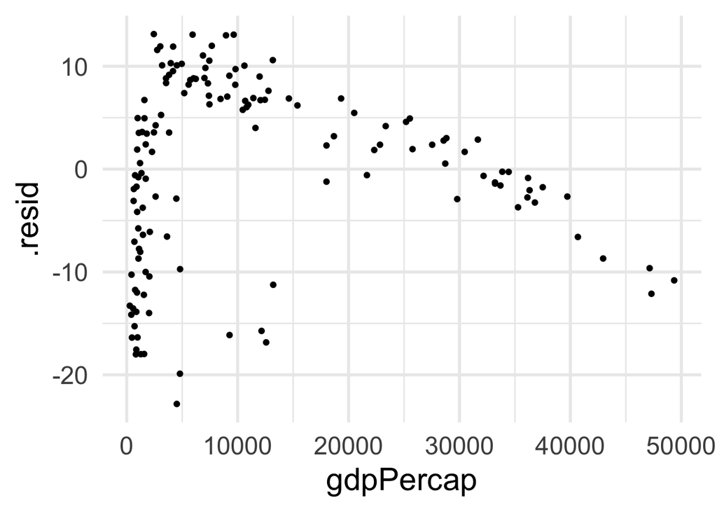

```r
augment(model_lm) %>%
  ggplot(aes(gdpPercap, .resid)) +
  geom_point()
```

Other diagnostics:

- Checking for (approximate) normality with quantile-quantile plot
- Checking for influential observations

[Cook’s distance](https://en.wikipedia.org/wiki/Cook%27s_distance), `cooksd` in the plots, measures how much the predictions for all other observations change if we leave out one observation

Point with high `cooksd` values

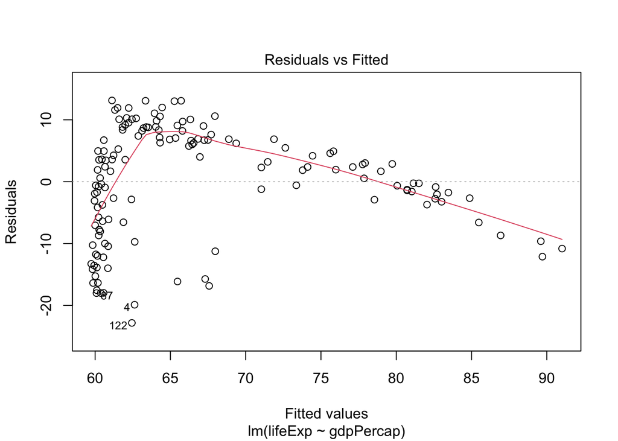

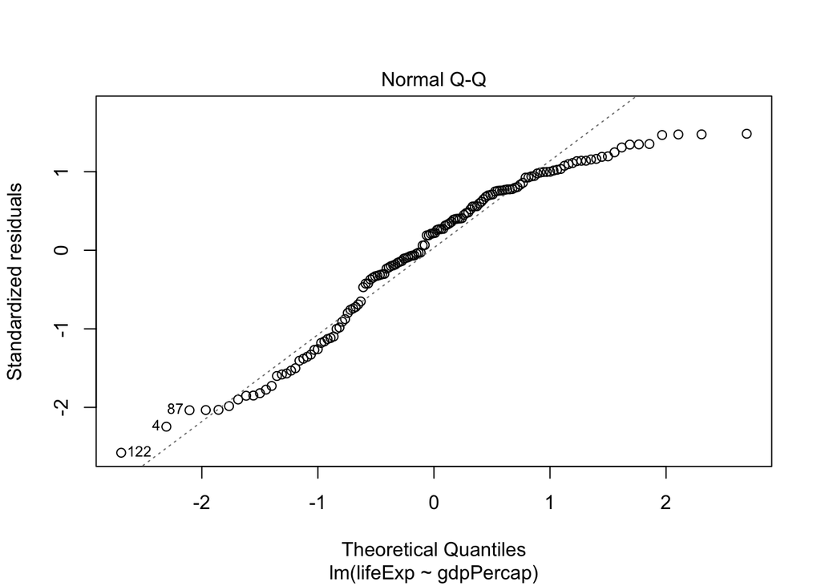

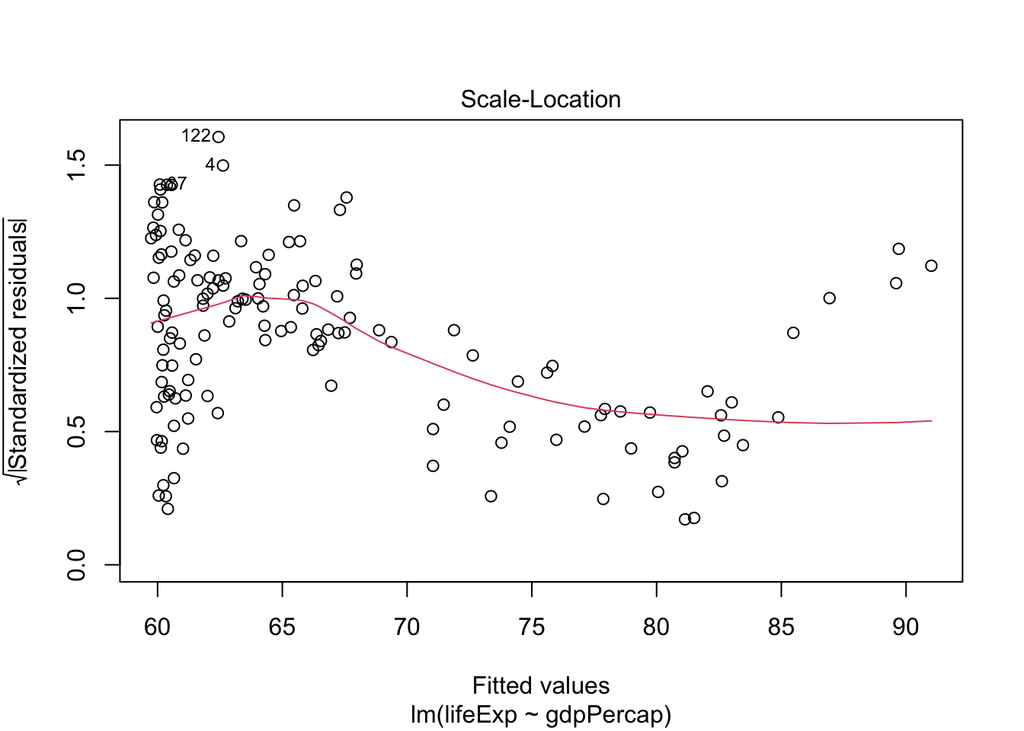

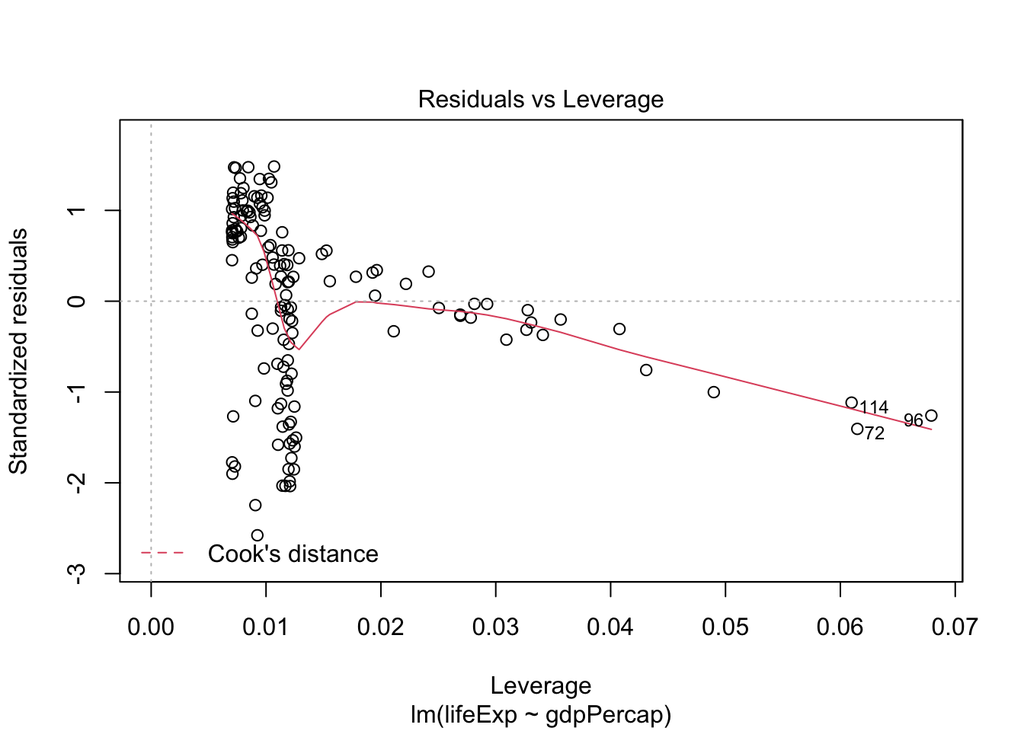

```r
plot(model_lm)
```

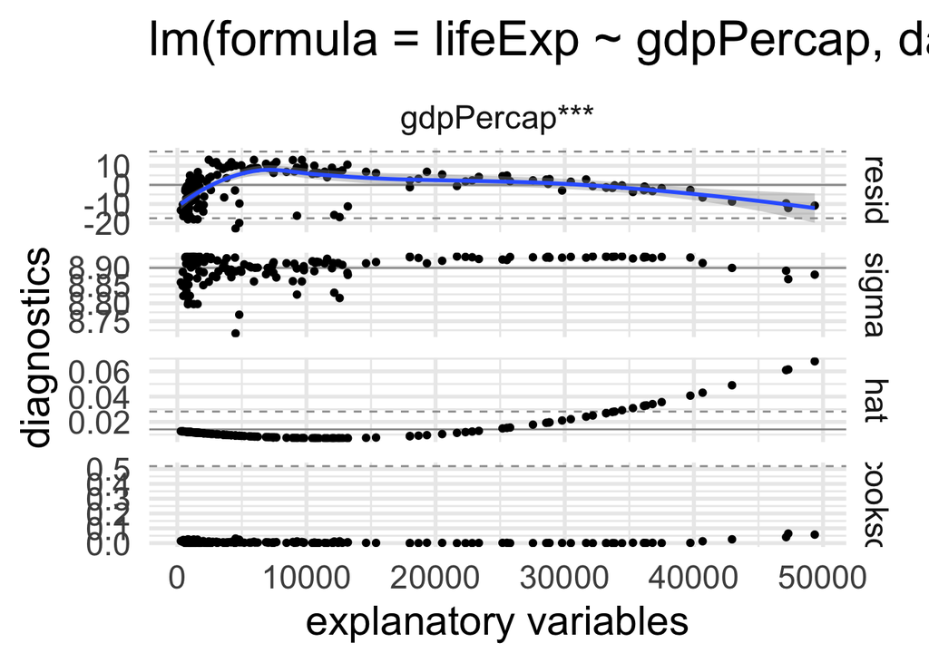

```r
library(GGally)
ggnostic(model_lm)
```

**Question**: with flexible models, are influential observations more or less harmful, and in which ways?

## Observation vs intervention

By default, conditional expectation functions–and therefore the linear models we use to approximate them–can only tell us about *observational* relationships. To make conclusions about *causal* relationships requires additional assumptions, and those additional assumptions are usually (even more) unrealistic (than linearity)

- Conditioning on `X = x` means we observe the subset of the data/population having a particular value of `X`
- Intervening to set `X = x` for a particular observation means we actually do something in the world–not just in the dataset–to change the value of `X`

This simple simulation shows the difference between these two kinds of relationships. In this simulation we know the true data generation process, so we know what would happen if we intervened to change the value of `X` for some observation: `Y` would be unchanged, because `Y` does not (functionally) depend on `X`

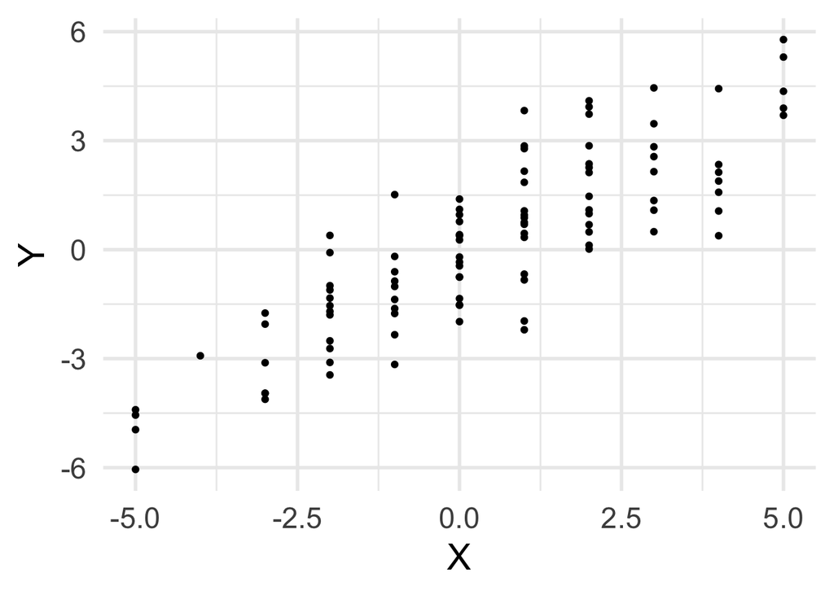

```r
n <- 100
U <- 2*rnorm(n)
X <- round(U + rnorm(n))
Y <- U + rnorm(n)
qplot(X,Y)
```

```r
lm(Y ~ X)
```

```
##
## Call:
## lm(formula = Y ~ X)
##
## Coefficients:
## (Intercept)            X
##     -0.2084       0.8540
```

Interpret the slope carefully! If we observe a different part of the population, having x values 1 larger than before, then these different part of the population has a larger (conditional) expected outcome

This is *not* the same thing as changing one observation’s x value, which is what people are probably most interested in.

Change `x` below and see the comparisons of average `Y` values after conditioning on different `X` values. This is an observational comparison. The regression slope captures and summarizes all of these comparisons

```r
x <- 3
mean(Y[X == x]) - mean(Y[X == x - 1])
```

```
## [1] 0.4251658
```

Now consider what happens if we run the same code but intervene and change `X` before generating `Y`

```r
X1 <- which(X == 1)
X1
```

```
##  [1]   1   5  15  19  26  41  45  51  52  65  83  84  85  89  96  99 100
```

```
U <- 2*rnorm(n)
X <- round(U + rnorm(n))
# change X here, like e.g.
X[X1] <- 2
Y <- U + rnorm(n)
```

Would the `Y` values for these intervened observations be any different? Would their average be larger by an amount close to the regression slope?

**Exercise**: Change the code generating the example above so that intervening on `X` results in a decrease in the average of `Y` for the observations whose `X` values are changed

**Question**: Suppose we could intervene and change a country’s GDP per capita and increase it by some amount. Would this change life expectancy, and if so would the change be roughly the amount captured by the regression coefficient in that data? Why or why not?

## Multiple regression

```r
candy <- fivethirtyeight::candy_rankings
```

### Inference

Hint: plot confidence intervals with `ggcoef`

### Problem: high dimensional plots…

e.g. `ggpairs` shows many 2-dimensional projections of the data, but there is no guarantee that these projections together help us understand higher dimensional relationships… including possibly higher dimensional patterns in the residuals

**Question**: What does this mean for diagnostic plots when our regression model is high dimensional (e.g. p > 3 predictors)